# 1122_ CE5033_112522081_HW1

2024-04-08

# 1.

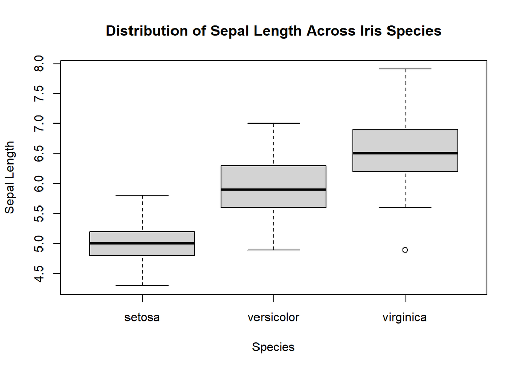

```r
# 載入所需的庫
library(ggplot2)
library(datasets)
library(dplyr)
# 讀取鳶尾花數據集
data(iris)

# 獲取盒狀圖中各物種的邊界數值
setosa_bounds <- range(iris$Sepal.Length[iris$Species == "setosa"])
versicolor_bounds <- range(iris$Sepal.Length[iris$Species == "versicolor"])
virginica_bounds <- range(iris$Sepal.Length[iris$Species == "virginica"])

# 使用 boxplot 函數生成盒狀圖
boxplot(Sepal.Length ~ Species, data = iris,
        main = "Distribution of Sepal Length Across Iris Species",
        xlab = "Species",
        ylab = "Sepal Length")
```

# 2.

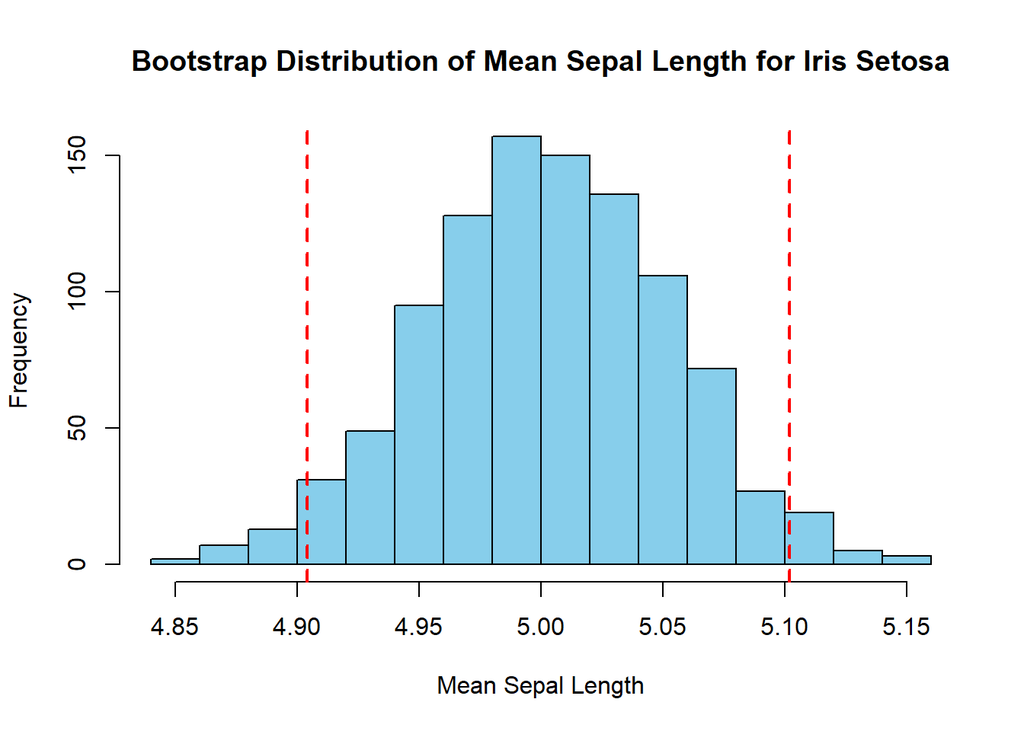

```r
# 選擇 Iris setosa 的數據
setosa_data <- iris %>% filter(Species == "setosa") %>% select(Sepal.Length)

# 執行 Bootstrap 重抽樣
n_bootstrap <- 1000  # 重抽樣次數
bootstrap_means <- replicate(n_bootstrap, mean(sample(setosa_data$Sepal.Length, replace = TRUE)))

# 計算95%信賴區間
lower_ci <- quantile(bootstrap_means, 0.025)
upper_ci <- quantile(bootstrap_means, 0.975)

# 視覺化 Bootstrap 平均值的分佈
hist(bootstrap_means, main = "Bootstrap Distribution of Mean Sepal Length for Iris Setosa",
     xlab = "Mean Sepal Length", ylab = "Frequency", col = "skyblue", border = "black")

# 添加信賴區間到直方圖
abline(v = lower_ci, col = "red", lwd = 2, lty = 2)
abline(v = upper_ci, col = "red", lwd = 2, lty = 2)
```

- 圖中信賴區間的左邊界大約在4.904，右邊界則約為5.10205。這表示有95%的信心Iris setosa的真實平均花萼長度大約在這兩個值之間。

# 3.

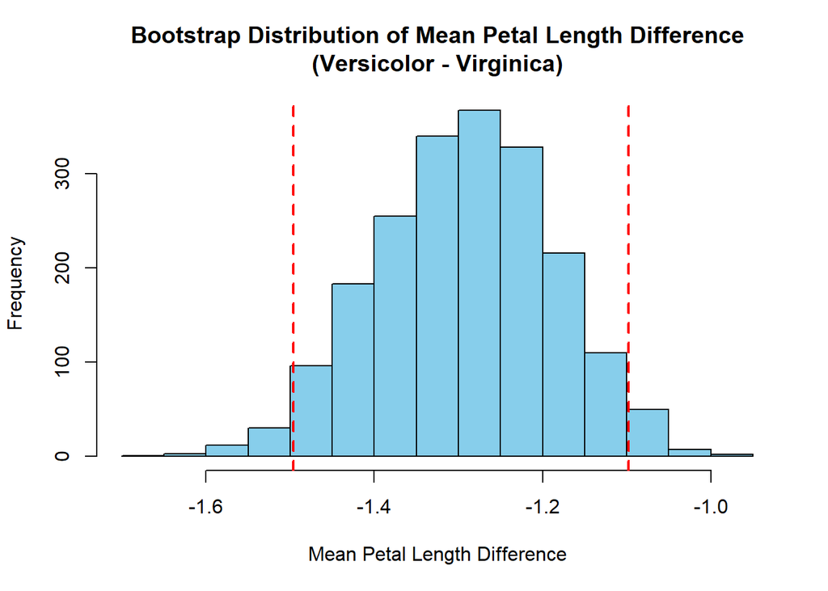

```r
# 選擇 Iris versicolor 和 Iris virginica 的數據
versicolor_data <- iris %>% filter(Species == "versicolor") %>% select(Petal.Length)
virginica_data <- iris %>% filter(Species == "virginica") %>% select(Petal.Length)

# 設定 Bootstrap 重抽樣次數
n_bootstrap <- 2000

# 執行 Bootstrap 重抽樣並計算平均差異
bootstrap_means_diff <- replicate(n_bootstrap, {
  mean(sample(versicolor_data$Petal.Length, replace = TRUE)) -
    mean(sample(virginica_data$Petal.Length, replace = TRUE))
})

# 計算 95% 信賴區間
lower_ci <- quantile(bootstrap_means_diff, 0.025)
upper_ci <- quantile(bootstrap_means_diff, 0.975)

# 視覺化平均差異的分佈
hist(bootstrap_means_diff, main = "Bootstrap Distribution of Mean Petal Length Difference\n(Versicolor - Virginica)",
     xlab = "Mean Petal Length Difference", ylab = "Frequency", col = "skyblue", border = "black")

# 添加信賴區間到直方圖
abline(v = lower_ci, col = "red", lwd = 2, lty = 2)
abline(v = upper_ci, col = "red", lwd = 2, lty = 2)
```

- 根據圖表，有95%的信心認為真正的平均差異值將落在-1.496至-1.09795之間。所有的平均差異值都是負數，這代表在所有自助樣本中，Iris versicolor的平均花瓣長度普遍低於Iris virginica。信賴區間不包括零，也就是說這兩個品種在花瓣長度上存在著顯著的差異。

## 第二題

```r
# 讀取 ToothGrowth 數據集
data(ToothGrowth)

# 執行單樣本 t 檢驗
t_test_result <- t.test(ToothGrowth$len, mu = 18.5)

# 解釋結果
if (t_test_result$p.value < 0.05) {
  cat("單樣本 t 檢驗的 p 值是：", t_test_result$p.value, "，拒絕零假設，認為維生素C對豚鼠的平均牙齒生長產生了顯著影響。\n")
} else {
  cat("單樣本 t 檢驗的 p 值是：",  t_test_result$p.value,"，無法拒絕零假設，認為維生素C對豚鼠的平均牙齒生長沒有顯著影響。\n")
}
```

```
## 單樣本 t 檢驗的 p 值是： 0.7521419 ，無法拒絕零假設，認為維生素C對豚鼠的平均牙齒生長沒有顯著影響。
```

## 第三題

```r
# 讀取 InsectSprays 數據集
data(InsectSprays)

# 提取噴霧 A 和噴霧 B 的數據
spray_A <- InsectSprays$count[InsectSprays$spray == "A"]
spray_B <- InsectSprays$count[InsectSprays$spray == "B"]

# 執行獨立樣本 t 檢驗
t_test_result <- t.test(spray_A, spray_B)

# 解釋結果
if (t_test_result$p.value < 0.05) {
  cat("獨立樣本 t 檢驗的 p 值是：", t_test_result$p.value,"，拒絕零假設，認為噴霧 A 和噴霧 B 的效果存在顯著差異。\n")
} else {
  cat("獨立樣本 t 檢驗的 p 值是：", t_test_result$p.value,"，無法拒絕零假設，認為噴霧 A 和噴霧 B 的效果沒有顯著差異。\n")
}
```

```
## 獨立樣本 t 檢驗的 p 值是： 0.6546567 ，無法拒絕零假設，認為噴霧 A 和噴霧 B 的效果沒有顯著差異。
```